# Random Effects Modeling

BH Analytics, LLC

# Objectives

- Overview of fixed versus random effects and shrinkage
- Hospital mortality example
- Benefits of random effects models
- Data example: Math achievement scores
- Formulating and Implementing a random intercept model
- Interpreting output
- Confidence intervals and p-values
- Adding random slopes to models
- Correlation between random effects
- Prediction from random effects models

# Linear Mixed Effects Models

- We will now discuss and implement a framework of models called generalized linear models, or linear mixed effect models.
- Before we get into the mathematical details, let’s step back and think about the goals of regression and how they are accomplished with standard general linear models.
- There is some underlying data generating process.
- We wish to make inference about this underlying data generating process, based on data we have observed.
- We summarize our inference on the data generating process through the parameter estimates in the model.
- Let’s use the hypothetical example of mortality rates at hospitals.
  - We have measured mortality rates on multiple hospitals from last year.
  - The hospitals have varying numbers of patients. Some are small (so we have less information about those hospitals), some are large (so we have more information about those hospitals).
  - If we look at last year’s mortality rates for each hospital, some have a higher mortality rate, and some have a lower mortality rate.
  - Let’s think about why there was differences in mortality rates in the first place! Is it because some hospitals give better or worse care (a true hospital level difference)? Or was it just random variation…the ‘bad’ hospitals had an unlucky year, and the ‘good’ hospitals had a lucky year?
  - How can we use last year’s mortality rates to identify which are ‘bad’ and which are ‘good’ hospitals?
  - Or stated differently…how can we use data from last year to identify the TRUE underlying mortality rate at each hospital?
  - Take a moment to try to come up with a few different ideas.

# Hospital Mortality

In order to understand this class of models, let’s first consider the problem of trying to identify hospital mortality amongst a bunch of different hospitals . Consider that the hospitals are all different sizes; we have small hospitals, and large hospitals. In addition to having different sizes the hospitals have very different mortality rates. If your task is to identify who is a good hospital, and who is about hospital, how would you go about doing it?

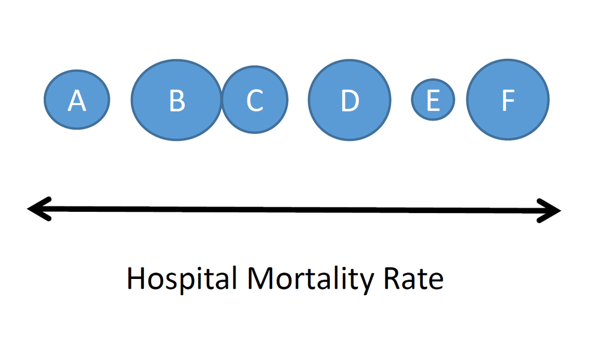

# Hospital Mortality

We could start by simply calculating the mortality rates and ranking the hospitals from best to worst based on their observed rate. This is what we do When we fit linear regression that you’ve already learned about. We call these fixed effects, which means we don’t share any information between the hospitals. We assume all the information we have about a single hospital is contained only within the data from that hospital . There is no information sharing between hospitals .

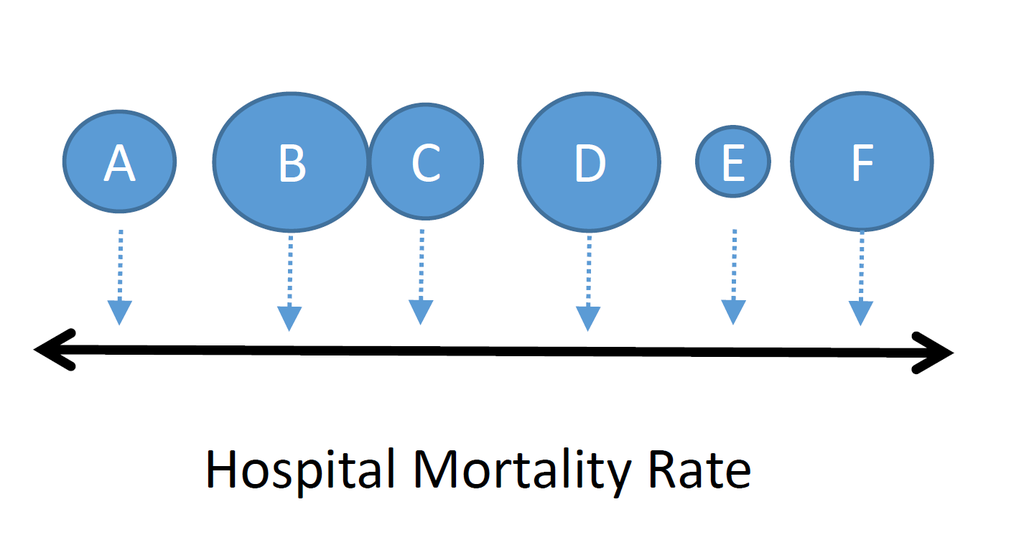

- Is that reasonable?
- Have you ever heard of the phrase regression to the mean?

# Hospital Mortality

An alternative approach is to try to share information between the hospitals. Basically, we are saying that even if a hospital has a really bad mortality rate, or a really good mortality rate , that is probably not their true rate. Their true rate is closer to the average, and they just had a good or a bad year.

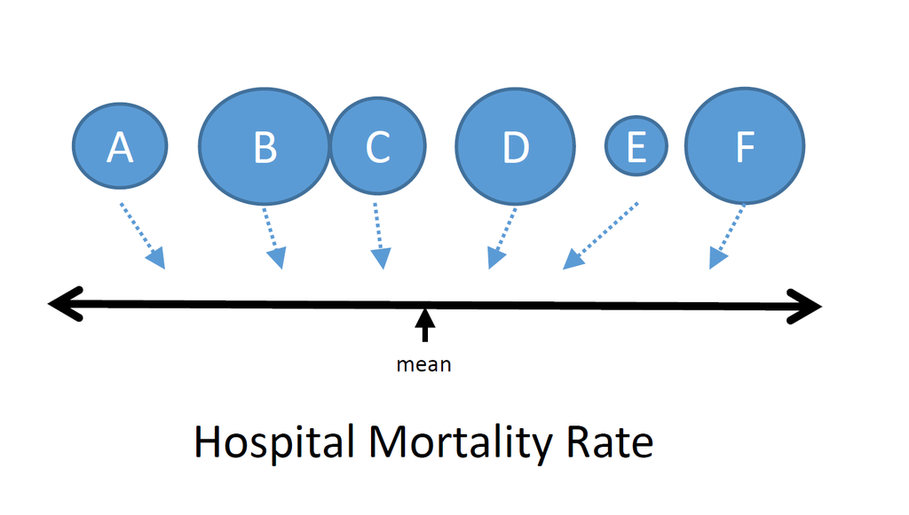

# Random Effects Versus Fixed Effects

- Fixed Effects
  - This is what you are familiar with from prior modeling experience. Everything was a fixed effect!
  - All information for that effect is held within the level of that effect
  - There is no ‘sharing’ of information across groups
  - Makes sense for categorical variables with a few unique levels
  - Gender, SES, smoking status
- Random Effects
  - Information from other levels should be shared to make inference for this effect
  - Regression to the mean
  - Categorical variables with lots of levels
  - Person ID, Hospital, Clinician, things that are “clusters”

# Benefits of Random Effects

- Potentially increased model accuracy. The ‘shrinkage’ effect that comes from sharing information across levels gives us better (less biased) model estimates.
- Less degrees of freedom
- Assumption of independence violations may be “fixed” with a random effect. Remember the assumption of ‘homogeneity’?
- We can quantify the “width” of variation within clusters. The actual random effects themselves may be of interest.
- We can compare the within cluster variation to the residual variation
- We accomplish this through additional variance components in the model (not additional fixed effects)

# Model Formulation

$$E(Y) = B_{0} + B_{1}*X_{1} + B_{2}*X_{2} + ... + B_{k}*X_{k} + e$$

- The traditional linear model formula includes an outcome, fixed effects with betas, and an error term.
- The addition of the random effects is often represented like below, with Z gamma as the random effects piece.
- We will not focus on the linear algebra here, but it is important to recall we are working with matrices.
- We could rewrite this considering X as a matrix, and Beta as a vector in our notation:

$$E(Y) = \mathbf B*\mathbf X + e$$

- Now we will add another component for the ‘random’ effects, typically noted as the **Z** matrix:

$$E(Y) = \mathbf X\mathbf \beta + \mathbf Z\mu + e$$

# MathAchieve Data

- Lets look at some data on math scores across schools to explore random effects modeling.
- This is the MathAchieve dataset from the nlme library. We will load the library just to use the data for now.
- The goal will be to make inference on the relationship between MathScores, Sex, minority, and SES, while considering the school clusters as either a fixed effect or a random effect.

```r
#### Math Achievement Studies data import
library(nlme) # load just for the data
library(data.table)
## import dataset, change class to regular dataframe
data(MathAchieve)
MathAchieve_dt <-
  data.table(as.data.frame(MathAchieve))
## Fix ordered factor issue that will cause problem later in the models
MathAchieve_dt[,School:=factor(School, ordered = FALSE)]
## Examine Data
MathAchieve_dt
```

```
##       School Minority    Sex    SES MathAch MEANSES
##    1:   1224       No Female -1.528   5.876  -0.428
##    2:   1224       No Female -0.588  19.708  -0.428
##    3:   1224       No   Male -0.528  20.349  -0.428
##    4:   1224       No   Male -0.668   8.781  -0.428
##    5:   1224       No   Male -0.158  17.898  -0.428
##   ---
## 7181:   9586       No Female  1.512  20.402   0.627
## 7182:   9586       No Female -0.038  14.794   0.627
## 7183:   9586       No Female  1.332  19.641   0.627
## 7184:   9586       No Female -0.008  16.241   0.627
## 7185:   9586       No Female  0.792  22.733   0.627
```

```r
summary(MathAchieve_dt)
```

```
##      School     Minority       Sex            SES               MathAch          MEANSES
##  2305   :  67   No :5211   Male  :3390   Min.   :-3.758000   Min.   :-2.832   Min.   :-1.188000
##  5619   :  66   Yes:1974   Female:3795   1st Qu.:-0.538000   1st Qu.: 7.275   1st Qu.:-0.317000
##  4292   :  65                            Median : 0.002000   Median :13.131   Median : 0.038000
##  8857   :  64                            Mean   : 0.000143   Mean   :12.748   Mean   : 0.006138
##  4042   :  64                            3rd Qu.: 0.602000   3rd Qu.:18.317   3rd Qu.: 0.333000
##  3610   :  64                            Max.   : 2.692000   Max.   :24.993   Max.   : 0.831000
##  (Other):6795
```

```r
library(Hmisc)
describe(MathAchieve_dt)
```

```
## MathAchieve_dt
##
##  6  Variables      7185  Observations
## --------------------------------------------------------------------------------------------------------------------------------------------------------
## School
##        n  missing distinct
##     7185        0      160
##
## lowest : 8367 8854 4458 5762 6990, highest: 8202 8627 8628 9198 9586
## --------------------------------------------------------------------------------------------------------------------------------------------------------
## Minority
##        n  missing distinct
##     7185        0        2
##
## Value         No   Yes
## Frequency   5211  1974
## Proportion 0.725 0.275
## --------------------------------------------------------------------------------------------------------------------------------------------------------
## Sex
##        n  missing distinct
##     7185        0        2
##
## Value        Male Female
## Frequency    3390   3795
## Proportion  0.472  0.528
## --------------------------------------------------------------------------------------------------------------------------------------------------------
## SES
##         n   missing  distinct      Info      Mean       Gmd       .05       .10       .25       .50       .75       .90       .95
##      7185         0       373         1 0.0001434    0.8877    -1.318    -1.038    -0.538     0.002     0.602     1.022     1.212
##
## lowest : -3.758 -2.838 -2.508 -2.498 -2.468, highest:  1.652  1.732  1.762  1.832  2.692
## --------------------------------------------------------------------------------------------------------------------------------------------------------
## MathAch
##        n  missing distinct     Info     Mean      Gmd      .05      .10      .25      .50      .75      .90      .95
##     7185        0     6031        1    12.75     7.91    1.210    3.301    7.275   13.131   18.317   22.016   23.123
##
## lowest : -2.832 -2.830 -2.721 -2.658 -2.657, highest: 24.677 24.707 24.812 24.869 24.993
## --------------------------------------------------------------------------------------------------------------------------------------------------------
## MEANSES
##        n  missing distinct     Info     Mean      Gmd      .05      .10      .25      .50      .75      .90      .95
##     7185        0      150        1 0.006138   0.4713   -0.696   -0.579   -0.317    0.038    0.333    0.523    0.661
##
## lowest : -1.188 -1.043 -0.958 -0.792 -0.756, highest:  0.688  0.718  0.749  0.759  0.831
## --------------------------------------------------------------------------------------------------------------------------------------------------------
```

# MathAchieve Data

- The outcome we will focus on is math scores. School will be our potential random effect.
- Let’s examine the distribution of the average math scores by school to see if that is a large source of variation.

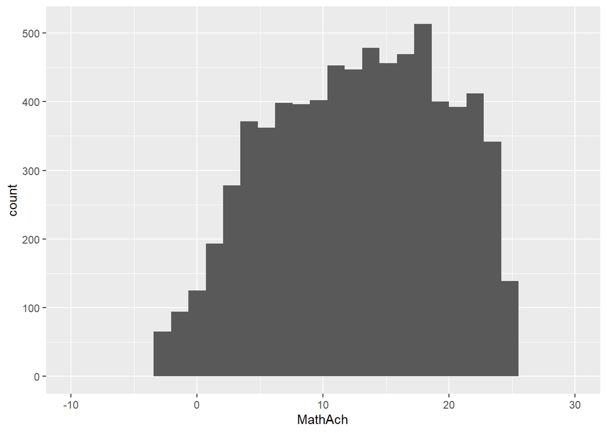

```r
## aggregate dataset
school_avg <-
  MathAchieve_dt[,list(MatchAchMean=mean(MathAch)),by=School]

## Create a plot showing the overall variation and school variation
library(ggplot2)
ggplot(MathAchieve_dt,aes(x=MathAch)) +
  geom_histogram() + xlim(c(-10,30))
```

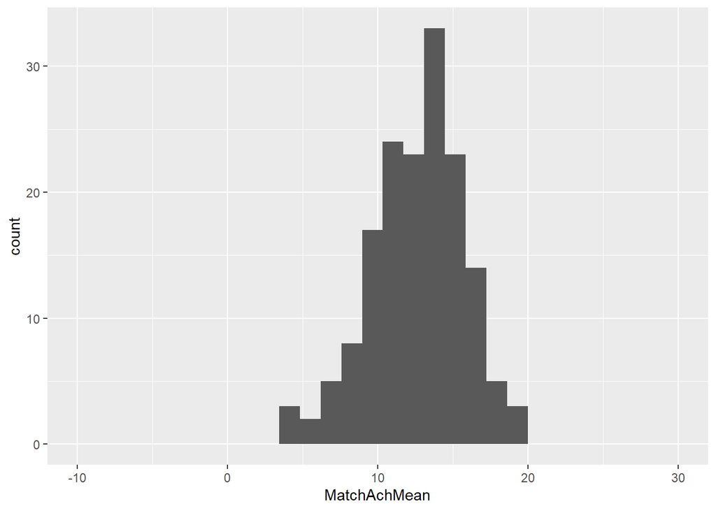

```r
ggplot(school_avg,aes(x=MatchAchMean)) +
  geom_histogram() + xlim(c(-10,30))
```

- It certainly looks like some schools have higher test scores, while others have lower test scores.
- The width of the histogram (the amount of variance by school) is pretty wide compared to the original histogram.
- We will need to decide on how to model school. Should it be a fixed effect, or a random effect?
- Let’s look at one more thing - the balance of the data across schools. Are schools all the same size? or is there a mixture of small and large schools?

```r
## Check out distribution of school sizes
describe(MathAchieve_dt[,.N,by=School])
```

```
## MathAchieve_dt[, .N, by = School]
##
##  2  Variables      160  Observations
## --------------------------------------------------------------------------------------------------------------------------------------------------------
## School
##        n  missing distinct
##      160        0      160
##
## lowest : 8367 8854 4458 5762 6990, highest: 8202 8627 8628 9198 9586
## --------------------------------------------------------------------------------------------------------------------------------------------------------
## N
##        n  missing distinct     Info     Mean      Gmd      .05      .10      .25      .50      .75      .90      .95
##      160        0       46    0.999    44.91    13.56    25.00    28.90    35.00    47.00    54.00    58.10    61.05
##
## lowest : 14 19 20 21 22, highest: 63 64 65 66 67
## --------------------------------------------------------------------------------------------------------------------------------------------------------
```

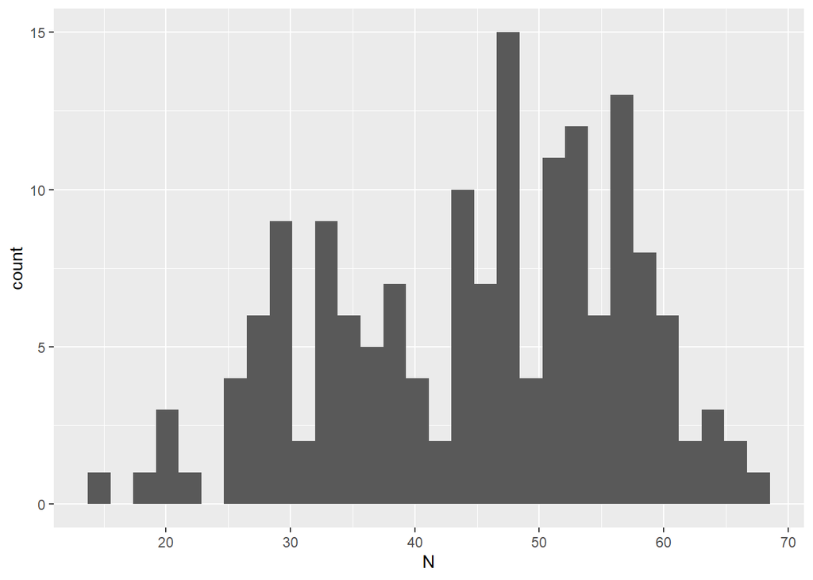

```r
ggplot(MathAchieve_dt[,.N,by=School],
       aes(N)) +
  geom_histogram()
```

- Schools are not all the same size!
- Some schools have a lot of students (over 50), some schools have less (less than 30).
- Is there any relationship between the number of students in a school, and the MathAchieve scores?

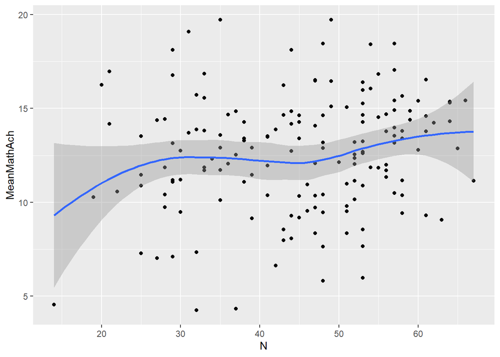

```r
## Investigate the number of students and mean score by school
ggplot(MathAchieve_dt[,list(.N,MeanMathAch=mean(MathAch)),by=School],
       aes(N,MeanMathAch)) +
  geom_point() +
  geom_smooth()
```

- I don’t see a strong relationship there. Often we will see that the smaller cluster sizes (Schools with few students) have unstable means (really high or low values) compared to the school with a large number of students. Why would that be true?
  - Possible small schools aren’t as good (a true effect)
  - But also possible small samples high a large amount of sampling variation! If you only have 3 students, they might all be high or low achieving students just by chance. The school might not be good or bad, we just have a small sample size (from that school). If you have 50+ students, it is less likely to have all 50 be high or low just by chance alone…so the bigger schools generally have stable means, because we have more data for them. This phenomena is termed ‘sampling variation’, and this is one reason we need random effects models! The shrinkage from random effect terms will stabilize these estimates. A fixed effect term would not.

# Standard Linear Model

- Let’s start with a standard linear model on this data.
- In that case, we will need to decide how to handle the ‘school’ variable. Should we ignore it and leave it out of the model? Or include it in the model as a fixed effect?
- We already looked at the mean score by school in the prior graph. Now, let’s fit a model with the other potential predictors without school. We can then aggregate the residuals across school.
- By examining the residuals, we can see if there are trends in the outcome associated with School that are not accounted for by the covariates.

```r
#### First fit our models
## Fit model without school
mod1lm <- lm(MathAch ~ Minority + Sex + SES,
             data=MathAchieve_dt)
summary(mod1lm)
```

```
##
## Call:
## lm(formula = MathAch ~ Minority + Sex + SES, data = MathAchieve_dt)
##
## Residuals:
##      Min       1Q   Median       3Q      Max
## -19.6401  -4.5587   0.2658   4.9098  17.5411
##
## Coefficients:
##             Estimate Std. Error t value Pr(>|t|)
## (Intercept) 14.25389    0.11775  121.05   <2e-16 ***
## MinorityYes -2.83651    0.17198  -16.49   <2e-16 ***
## SexFemale   -1.37665    0.14835   -9.28   <2e-16 ***
## SES          2.68299    0.09873   27.18   <2e-16 ***
## ---
## Signif. codes:  0 '***' 0.001 '**' 0.01 '*' 0.05 '.' 0.1 ' ' 1
##
## Residual standard error: 6.263 on 7181 degrees of freedom
## Multiple R-squared:  0.1713, Adjusted R-squared:  0.171
## F-statistic: 494.8 on 3 and 7181 DF,  p-value: < 2.2e-16
```

- How can we explore the potential effect of school using the first model? We could examine the residuals from the model, and aggregate them across the school…

```r
## Make data frame of residuals and school id:
dt1 <- data.table(School=MathAchieve_dt$School,
                  mod1Resid = residuals(mod1lm))
dt1
```

```
##       School mod1Resid
##    1:   1224 -2.901637
##    2:   1224  8.408353
##    3:   1224  7.511728
##    4:   1224 -3.680653
##    5:   1224  4.068022
##   ---
## 7181:   9586  3.468074
## 7182:   9586  2.018709
## 7183:   9586  3.190012
## 7184:   9586  3.385219
## 7185:   9586  7.730827
```

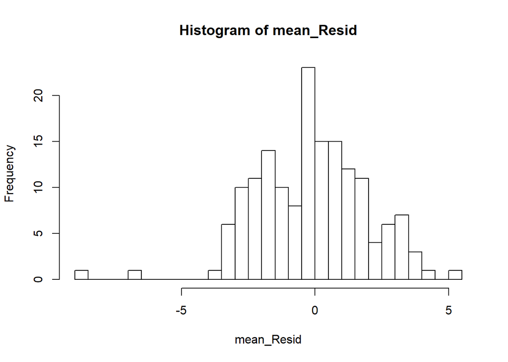

```
## $breaks
##  [1] -9.0 -8.5 -8.0 -7.5 -7.0 -6.5 -6.0 -5.5 -5.0 -4.5 -4.0 -3.5 -3.0 -2.5 -2.0 -1.5 -1.0 -0.5  0.0  0.5  1.0  1.5  2.0  2.5  3.0  3.5  4.0  4.5  5.0
## [30]  5.5
##
## $counts
##  [1]  1  0  0  0  1  0  0  0  0  0  1  6 10 11 14 10  8 23 15 15 12 11  4  6  7  3  1  0  1
##
## $density
##  [1] 0.0125 0.0000 0.0000 0.0000 0.0125 0.0000 0.0000 0.0000 0.0000 0.0000 0.0125 0.0750 0.1250 0.1375 0.1750 0.1250 0.1000 0.2875 0.1875 0.1875 0.1500
## [22] 0.1375 0.0500 0.0750 0.0875 0.0375 0.0125 0.0000 0.0125
##
## $mids
##  [1] -8.75 -8.25 -7.75 -7.25 -6.75 -6.25 -5.75 -5.25 -4.75 -4.25 -3.75 -3.25 -2.75 -2.25 -1.75 -1.25 -0.75 -0.25  0.25  0.75  1.25  1.75  2.25  2.75
## [25]  3.25  3.75  4.25  4.75  5.25
##
## $xname
## [1] "mean_Resid"
##
## $equidist
## [1] TRUE
##
## attr(,"class")
## [1] "histogram"
```

```r
## get mean residuals by school
dt1[,list(mean_Resid=mean(mod1Resid)),
    by=School][,hist(mean_Resid,breaks = 30)]
```

```r
## look at distribution (histogram)
```

- It certainly seems like we need to adjust for school somehow. Even after adjusting for the other variables, there is still quite a bit of variation by school. Some schools are 5 above the mean, while others are 5 below the mean. There are two school that seem like outliers on the low side.

# Random Intercept

- How do we account for the clustering within schools?
- If we try to include a fixed effect for school, how many degrees of freedom will this use?

```r
length(unique(MathAchieve$School)) # 160, so 159 predictors needed...
```

```
## [1] 160
```

```r
# Perhaps the model is oversaturated here...
## Include School as a fixed effect in this model
mod2lm <- lm(MathAch ~ Minority + Sex + SES + School,
             data=MathAchieve_dt)
summary(mod2lm)
```

```
##
## Call:
## lm(formula = MathAch ~ Minority + Sex + SES + School, data = MathAchieve_dt)
##
## Residuals:
##      Min       1Q   Median       3Q      Max
## -19.4942  -4.3357   0.1933   4.4469  17.5434
##
## Coefficients:
##             Estimate Std. Error t value Pr(>|t|)
## (Intercept)   5.5031     1.6034   3.432 0.000602 ***
## MinorityYes  -2.9242     0.2194 -13.326  < 2e-16 ***
## SexFemale    -1.1630     0.1679  -6.927 4.67e-12 ***
## SES           1.9122     0.1087  17.598  < 2e-16 ***
## School8854    1.3498     1.9212   0.703 0.482342
## School4458    5.3084     1.8272   2.905 0.003682 **
## School5762    4.3729     1.8894   2.314 0.020674 *
## School6990    5.0364     1.8097   2.783 0.005401 **
## School5815    4.8894     2.0014   2.443 0.014590 *
## School7172    6.4242     1.8459   3.480 0.000504 ***
## School4868    7.7829     1.9040   4.088 4.41e-05 ***
## School7341    5.9998     1.8076   3.319 0.000907 ***
## School1358    6.4596     1.9389   3.332 0.000868 ***
## School4383    6.9896     1.9997   3.495 0.000476 ***
## School2305   10.7917     1.7714   6.092 1.17e-09 ***
## School8800    6.5451     1.9265   3.397 0.000684 ***
## School3088    6.8972     1.8691   3.690 0.000226 ***
## School8775    5.9259     1.8199   3.256 0.001135 **
## School7890    4.6714     1.8084   2.583 0.009808 **
## School6144    5.1266     1.8439   2.780 0.005444 **
## School6443    6.4949     1.9398   3.348 0.000818 ***
## School5192    6.3823     1.9608   3.255 0.001140 **
## School6808    6.0233     1.8395   3.274 0.001064 **
## School2818    8.8407     1.8487   4.782 1.77e-06 ***
## School9340    7.1570     1.9504   3.670 0.000245 ***
## School4523    6.9763     1.8349   3.802 0.000145 ***
## School6816   11.5261     1.8027   6.394 1.72e-10 ***
## School2277    8.6675     1.7833   4.860 1.20e-06 ***
## School8009    8.5911     1.8271   4.702 2.62e-06 ***
## School5783    8.7039     1.9497   4.464 8.16e-06 ***
```

[output cut: 124 more lines]

```
## School7345    7.1574     1.7901   3.998 6.44e-05 ***
## School7688   12.8345     1.7985   7.136 1.05e-12 ***
## School7697   10.1246     1.9199   5.273 1.38e-07 ***
## School8193   11.8149     1.8453   6.403 1.63e-10 ***
## School8202    7.2113     1.8943   3.807 0.000142 ***
## School8627    6.2033     1.8000   3.446 0.000572 ***
## School8628   11.9599     1.7756   6.736 1.76e-11 ***
## School9198   12.6484     1.9313   6.549 6.20e-11 ***
## School9586    9.4845     1.7840   5.316 1.09e-07 ***
## ---
## Signif. codes:  0 '***' 0.001 '**' 0.01 '*' 0.05 '.' 0.1 ' ' 1
##
## Residual standard error: 5.99 on 7022 degrees of freedom
## Multiple R-squared:  0.2587, Adjusted R-squared:  0.2416
## F-statistic: 15.13 on 162 and 7022 DF,  p-value: < 2.2e-16
```

- Each one of those estimates can be interpreted identically as the residuals we calculated above. Each schoolID is (on average) above or below the mean, after adjusting for the other variables in the model. That is exactly what we calculated by hand a moment ago and graphed when we did the residual thing. Now we also have confidence intervales associated with these estimates.
- However…what if we need to stabilize these estimates a bit? Shrink them towards the overall mean?
- Let’s consider a random effect using the lme4 package.

```r
library(lme4)
## Just a random effect
mod1lmer <- lmer(MathAch ~ (1|School),
               data=MathAchieve_dt)
summary(mod1lmer)
```

```
## Linear mixed model fit by REML. t-tests use Satterthwaite's method ['lmerModLmerTest']
## Formula: MathAch ~ (1 | School)
##    Data: MathAchieve_dt
##
## REML criterion at convergence: 47116.8
##
## Scaled residuals:
##     Min      1Q  Median      3Q     Max
## -3.0631 -0.7539  0.0267  0.7606  2.7426
##
## Random effects:
##  Groups   Name        Variance Std.Dev.
##  School   (Intercept)  8.614   2.935
##  Residual             39.148   6.257
## Number of obs: 7185, groups:  School, 160
##
## Fixed effects:
##             Estimate Std. Error       df t value Pr(>|t|)
## (Intercept)  12.6370     0.2444 156.6473   51.71   <2e-16 ***
## ---
## Signif. codes:  0 '***' 0.001 '**' 0.01 '*' 0.05 '.' 0.1 ' ' 1
```

```r
## Some convenience functions
fixef(mod1lmer)
```

```
## (Intercept)
##    12.63697
```

```r
ranef(mod1lmer)
```

```
## $School
##      (Intercept)
## 8367 -6.10301152
## 8854 -7.35291363
## 4458 -6.23521734
## 5762 -7.40281891
## 6990 -6.13417910
## 5815 -4.54024780
## 7172 -4.14230120
## 4868 -0.28826542
## 7341 -2.61019710
## 1358 -1.24251161
## 4383 -0.99111944
## 2305 -1.40397847
## 8800 -4.64179687
```

[output cut: 149 more lines]

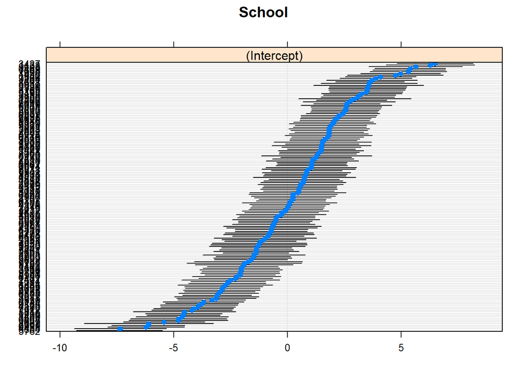

```r
## View random effects using lattice package
## There is a nice automatic function here, or you could write the longer ggplot function...
library(lattice)
dotplot(ranef(mod1lmer))
```

# Fixed Effects and Random Effects

- We can add fixed effects in with the random intercept easily
- the ‘1’ prior to the vertical bar is referencing the intercept. It means add a random effect for the intercept, grouped by School. We term that a random intercept for school.

```r
## add in fixed effects
mod2lmer <- lmer(MathAch ~ Minority + Sex + SES + (1|School),
                 data=MathAchieve_dt)
summary(mod2lmer)
```

```
## Linear mixed model fit by REML. t-tests use Satterthwaite's method ['lmerModLmerTest']
## Formula: MathAch ~ Minority + Sex + SES + (1 | School)
##    Data: MathAchieve_dt
##
## REML criterion at convergence: 46394.4
##
## Scaled residuals:
##     Min      1Q  Median      3Q     Max
## -3.2427 -0.7216  0.0342  0.7620  2.8631
##
## Random effects:
##  Groups   Name        Variance Std.Dev.
##  School   (Intercept)  3.674   1.917
##  Residual             35.909   5.992
## Number of obs: 7185, groups:  School, 160
##
## Fixed effects:
##              Estimate Std. Error        df t value Pr(>|t|)
## (Intercept)   14.1145     0.1970  262.9414  71.637  < 2e-16 ***
## MinorityYes   -2.9615     0.2058 4829.9862 -14.393  < 2e-16 ***
## SexFemale     -1.2298     0.1627 6640.5850  -7.558 4.64e-14 ***
## SES            2.0894     0.1057 6831.7168  19.766  < 2e-16 ***
## ---
## Signif. codes:  0 '***' 0.001 '**' 0.01 '*' 0.05 '.' 0.1 ' ' 1
##
## Correlation of Fixed Effects:
##             (Intr) MnrtyY SexFml
## MinorityYes -0.292
## SexFemale   -0.434  0.014
## SES         -0.078  0.195  0.058
```

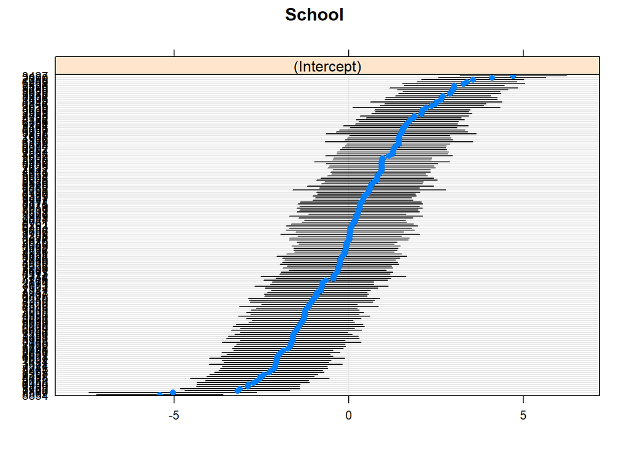

```r
dotplot(ranef(mod2lmer))
```

# Confidence Intervals

- The authors of the lme4 package provide a confint function to calculate confidence intervals
- These can be Wald, profile likelihood based, or bootstrapped. You should get similar results across these different methods. There are disagreements in the statistical literature on which method is ‘best’, so I present all three here for completeness.
- you will notice the bootstrapped confidence intervals take a minute.

```r
confint(mod2lmer,method="Wald")
```

```
##                 2.5 %     97.5 %
## .sig01             NA         NA
## .sigma             NA         NA
## (Intercept) 13.728343 14.5006792
## MinorityYes -3.364745 -2.5581986
## SexFemale   -1.548697 -0.9108916
## SES          1.882244  2.2966035
```

```r
confint(mod2lmer,method="profile")
```

```
##                 2.5 %    97.5 %
## .sig01       1.659637  2.195890
## .sigma       5.893485  6.091795
## (Intercept) 13.727237 14.500422
## MinorityYes -3.364670 -2.558466
## SexFemale   -1.549277 -0.911110
## SES          1.880070  2.301327
```

```r
confint(mod2lmer,method="boot")
```

```
##                 2.5 %     97.5 %
## .sig01       1.636649  2.1559521
## .sigma       5.882540  6.0939745
## (Intercept) 13.718056 14.4955998
## MinorityYes -3.341039 -2.5576924
## SexFemale   -1.524798 -0.8923466
## SES          1.883278  2.3024725
```

# Random Effects P Values?

- P Values are intentionally excluded by default in lme4
- This is due to the complexities associated with calculating p-values. The authors felt they should not be easily available without considering those complexities!
- The lmerTest package overides some methods in lme4 and adds in p-values parallel to the p values calculated in other software.

```r
library(lmerTest)
## add in fixed effects
mod2lmer <- lmer(MathAch ~ Minority + Sex + SES + (1|School),
                 data=MathAchieve)
summary(mod2lmer)
```

```
## Linear mixed model fit by REML. t-tests use Satterthwaite's method ['lmerModLmerTest']
## Formula: MathAch ~ Minority + Sex + SES + (1 | School)
##    Data: MathAchieve
##
## REML criterion at convergence: 46394.4
##
## Scaled residuals:
##     Min      1Q  Median      3Q     Max
## -3.2427 -0.7216  0.0342  0.7620  2.8631
##
## Random effects:
##  Groups   Name        Variance Std.Dev.
##  School   (Intercept)  3.674   1.917
##  Residual             35.909   5.992
## Number of obs: 7185, groups:  School, 160
##
## Fixed effects:
##              Estimate Std. Error        df t value Pr(>|t|)
## (Intercept)   14.1145     0.1970  262.9414  71.637  < 2e-16 ***
## MinorityYes   -2.9615     0.2058 4829.9862 -14.393  < 2e-16 ***
## SexFemale     -1.2298     0.1627 6640.5850  -7.558 4.64e-14 ***
## SES            2.0894     0.1057 6831.7168  19.766  < 2e-16 ***
## ---
## Signif. codes:  0 '***' 0.001 '**' 0.01 '*' 0.05 '.' 0.1 ' ' 1
##
## Correlation of Fixed Effects:
##             (Intr) MnrtyY SexFml
## MinorityYes -0.292
## SexFemale   -0.434  0.014
## SES         -0.078  0.195  0.058
```

# Intraclass Correlation Coefficient

- One way to summarize and contextualize the random intercept components in this sort of model is called the ‘intraclass correlation coefficient’. The idea is to describe the size of the variance component fit from the random intercept as a proportion of the total variance.
- We might interpret this quantity by saying ‘The proportion of variance explained by the grouping structure in the population’.
- For this problem, we would explain it as ‘the proportion of variance in achievement scores explained by school’.
- Let’s re-examine the first random intercept model and use it to calculate the ICC.

```r
## Just a single random effect
mod1lmer <- lmer(MathAch ~ (1|School),
               data=MathAchieve_dt)
summary(mod1lmer)
```

```
## Linear mixed model fit by REML. t-tests use Satterthwaite's method ['lmerModLmerTest']
## Formula: MathAch ~ (1 | School)
##    Data: MathAchieve_dt
##
## REML criterion at convergence: 47116.8
##
## Scaled residuals:
##     Min      1Q  Median      3Q     Max
## -3.0631 -0.7539  0.0267  0.7606  2.7426
##
## Random effects:
##  Groups   Name        Variance Std.Dev.
##  School   (Intercept)  8.614   2.935
##  Residual             39.148   6.257
## Number of obs: 7185, groups:  School, 160
##
## Fixed effects:
##             Estimate Std. Error       df t value Pr(>|t|)
## (Intercept)  12.6370     0.2444 156.6473   51.71   <2e-16 ***
## ---
## Signif. codes:  0 '***' 0.001 '**' 0.01 '*' 0.05 '.' 0.1 ' ' 1
```

```r
## Calculate ICC
8.614/(8.614+39.148)
```

```
## [1] 0.1803526
```

- You can also do this for the conditional model (the model with the fixed effects added in)

```r
mod2lmer <- lmer(MathAch ~ Minority + Sex + SES + (1|School),
                 data=MathAchieve_dt)
summary(mod2lmer)
```

```
## Linear mixed model fit by REML. t-tests use Satterthwaite's method ['lmerModLmerTest']
## Formula: MathAch ~ Minority + Sex + SES + (1 | School)
##    Data: MathAchieve_dt
##
## REML criterion at convergence: 46394.4
##
## Scaled residuals:
##     Min      1Q  Median      3Q     Max
## -3.2427 -0.7216  0.0342  0.7620  2.8631
##
## Random effects:
##  Groups   Name        Variance Std.Dev.
##  School   (Intercept)  3.674   1.917
##  Residual             35.909   5.992
## Number of obs: 7185, groups:  School, 160
##
## Fixed effects:
##              Estimate Std. Error        df t value Pr(>|t|)
## (Intercept)   14.1145     0.1970  262.9414  71.637  < 2e-16 ***
## MinorityYes   -2.9615     0.2058 4829.9862 -14.393  < 2e-16 ***
## SexFemale     -1.2298     0.1627 6640.5850  -7.558 4.64e-14 ***
## SES            2.0894     0.1057 6831.7168  19.766  < 2e-16 ***
## ---
## Signif. codes:  0 '***' 0.001 '**' 0.01 '*' 0.05 '.' 0.1 ' ' 1
##
## Correlation of Fixed Effects:
##             (Intr) MnrtyY SexFml
## MinorityYes -0.292
## SexFemale   -0.434  0.014
## SES         -0.078  0.195  0.058
```

```r
# Calculate ICC
3.674/(3.674+35.909)
```

```
## [1] 0.09281762
```

- After adjusting for the other variables, school becomes less important. It now only accounts for 9% of the total variance (ICC = 0.09)

# Random Slopes

- Is it possible that at some schools, the relationship between SES and Math scores is lower or higher than at other schools?
- Stated differently…perhaps SES really matters for predicting math scores for some schools. But at other schools, the relationship is less important?
- How would we model this without random effects?
- We would need a different interaction term for every school!
- That means a different slope estimate for each school.

```r
## Here is the code to fit the ineraction.
##How many predictors did I just put into the model...?
mod3lm <-
  lm(MathAch ~ Minority + Sex + SES*School,
     data=MathAchieve_dt)
## Can you interpret these results?
summary(mod3lm)
```

```
##
## Call:
## lm(formula = MathAch ~ Minority + Sex + SES * School, data = MathAchieve_dt)
##
## Residuals:
##      Min       1Q   Median       3Q      Max
## -19.5981  -4.2371   0.1852   4.3701  17.6652
##
## Coefficients:
##                Estimate Std. Error t value Pr(>|t|)
## (Intercept)     5.50961    1.59985   3.444 0.000577 ***
## MinorityYes    -2.89135    0.22558 -12.818  < 2e-16 ***
## SexFemale      -1.09355    0.16935  -6.457 1.14e-10 ***
## SES             0.11746    2.19303   0.054 0.957288
## School8854      0.98712    2.16485   0.456 0.648422
## School4458      3.72048    2.30367   1.615 0.106351
## School5762      0.90213    2.97720   0.303 0.761889
## School6990      4.47886    1.86721   2.399 0.016480 *
## School5815      4.73448    2.46647   1.920 0.054958 .
## School7172      6.11258    1.88338   3.246 0.001178 **
## School4868      8.33898    1.97255   4.228 2.39e-05 ***
## School7341      5.84291    1.81045   3.227 0.001255 **
## School1358      6.47232    1.93445   3.346 0.000825 ***
## School4383      6.71489    2.00057   3.356 0.000794 ***
## School2305      9.00650    1.90291   4.733 2.26e-06 ***
## School8800      6.68931    2.16391   3.091 0.002001 **
## School3088      6.38320    1.94936   3.275 0.001064 **
## School8775      5.36345    1.86811   2.871 0.004103 **
## School7890      3.40475    1.95058   1.746 0.080941 .
## School6144      5.30292    1.92250   2.758 0.005825 **
## School6443      5.34971    2.00036   2.674 0.007505 **
## School5192      6.30726    1.95814   3.221 0.001283 **
## School6808      5.93311    1.83820   3.228 0.001254 **
## School2818      8.67960    1.85149   4.688 2.81e-06 ***
## School9340      7.63214    2.09696   3.640 0.000275 ***
## School4523      6.88930    1.83237   3.760 0.000171 ***
## School6816     11.79954    1.89785   6.217 5.35e-10 ***
## School2277      5.57939    1.98635   2.809 0.004986 **
## School8009      8.91693    1.99266   4.475 7.77e-06 ***
## School5783      8.42715    1.96140   4.297 1.76e-05 ***
```

[output cut: 162 more lines]

```
## SES:School9021  2.13870    2.58852   0.826 0.408704
## SES:School4511  0.31153    2.58131   0.121 0.903944
## SES:School2639 -0.91033    2.66156  -0.342 0.732340
## SES:School3377 -1.24129    2.54974  -0.487 0.626395
## SES:School6578  2.05164    2.54348   0.807 0.419909
## SES:School9347  2.83867    2.48282   1.143 0.252943
## SES:School3705  0.07753    2.55580   0.030 0.975802
## SES:School3533 -0.10038    2.72726  -0.037 0.970641
##  [ reached getOption("max.print") -- omitted 122 rows ]
## ---
## Signif. codes:  0 '***' 0.001 '**' 0.01 '*' 0.05 '.' 0.1 ' ' 1
##
## Residual standard error: 5.973 on 6863 degrees of freedom
## Multiple R-squared:  0.2797, Adjusted R-squared:  0.246
## F-statistic: 8.301 on 321 and 6863 DF,  p-value: < 2.2e-16
```

# Random Slopes in lme4

- We can add in random slopes by specifying the effect, then the cluster
- We will get ‘shrinkage’ estimates for the slopes in this case.
- We are still estimating a slope for each school, but they are going to be ‘shrunk’ towards the mean slope across all schools.

```r
## Fit model with random intercept and slope
mod3lmer <-
  lmer(MathAch ~ Minority + Sex + SES + (1|School) +
         (0+SES|School),
       data=MathAchieve)
## Equivalent way to fit the model
mod3lmer <-
  lmer(MathAch ~ Minority + Sex + SES + (SES||School),
       data=MathAchieve)
summary(mod3lmer)
```

```
## Linear mixed model fit by REML. t-tests use Satterthwaite's method ['lmerModLmerTest']
## Formula: MathAch ~ Minority + Sex + SES + (SES || School)
##    Data: MathAchieve
##
## REML criterion at convergence: 46391.9
##
## Scaled residuals:
##     Min      1Q  Median      3Q     Max
## -3.2249 -0.7214  0.0336  0.7606  2.8672
##
## Random effects:
##  Groups   Name        Variance Std.Dev.
##  School   (Intercept)  3.6910  1.9212
##  School.1 SES          0.2942  0.5424
##  Residual             35.7663  5.9805
## Number of obs: 7185, groups:  School, 160
##
## Fixed effects:
##              Estimate Std. Error        df t value Pr(>|t|)
## (Intercept)   14.1024     0.1979  258.3572  71.277  < 2e-16 ***
## MinorityYes   -2.9631     0.2063 4712.4112 -14.361  < 2e-16 ***
## SexFemale     -1.2207     0.1627 6661.0210  -7.502 7.08e-14 ***
## SES            2.0971     0.1147  168.9611  18.290  < 2e-16 ***
## ---
## Signif. codes:  0 '***' 0.001 '**' 0.01 '*' 0.05 '.' 0.1 ' ' 1
##
## Correlation of Fixed Effects:
##             (Intr) MnrtyY SexFml
## MinorityYes -0.290
## SexFemale   -0.432  0.014
## SES         -0.074  0.179  0.054
```

```r
anova(mod3lmer)
```

```
## Type III Analysis of Variance Table with Satterthwaite's method
##           Sum Sq Mean Sq NumDF  DenDF F value    Pr(>F)
## Minority  7376.7  7376.7     1 4712.4 206.247 < 2.2e-16 ***
## Sex       2013.2  2013.2     1 6661.0  56.287 7.079e-14 ***
## SES      11964.5 11964.5     1  169.0 334.520 < 2.2e-16 ***
## ---
## Signif. codes:  0 '***' 0.001 '**' 0.01 '*' 0.05 '.' 0.1 ' ' 1
```

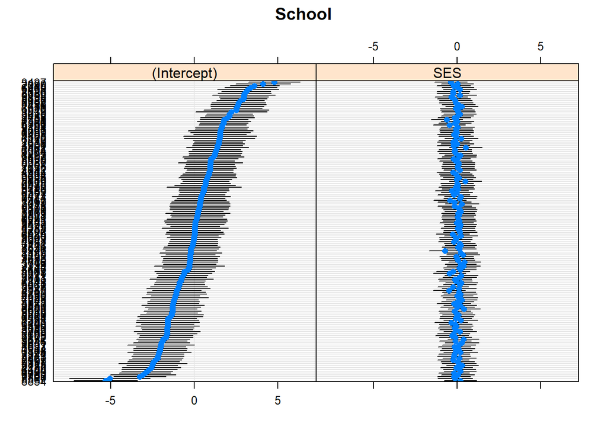

```r
dotplot(ranef(mod3lmer))
```

# Random Slope, Intercept, and Correlation between them

- Another layer of complexity that can be added to these sort of random effects models is the correlation between random effects.
- In the prior model we just fit, we assumed there was no correlation between the random intercept and the random slope. However, what if we suspected that schools with a higher baseline test score also had a higher relationship between SES and test scores?
- It is possible that clusters with high intercepts tend to have high slopes (or some other relationship between random effects)
- We can model this by estimating the actual correlation between the random intercept and random slope. The syntax is subtle…if we use the single `|`, we are allowing correlations between random effects. If we use the `||`, we are not.

```r
mod4lmer <- lmer(MathAch ~ Minority + Sex + SES + (SES|School),
           data=MathAchieve_dt)
summary(mod4lmer)
```

```
## Linear mixed model fit by REML. t-tests use Satterthwaite's method ['lmerModLmerTest']
## Formula: MathAch ~ Minority + Sex + SES + (SES | School)
##    Data: MathAchieve_dt
##
## REML criterion at convergence: 46389.1
##
## Scaled residuals:
##     Min      1Q  Median      3Q     Max
## -3.2025 -0.7195  0.0373  0.7638  2.8871
##
## Random effects:
##  Groups   Name        Variance Std.Dev. Corr
##  School   (Intercept)  3.6598  1.9131
##           SES          0.2598  0.5097   -0.43
##  Residual             35.7878  5.9823
## Number of obs: 7185, groups:  School, 160
##
## Fixed effects:
##              Estimate Std. Error        df t value Pr(>|t|)
## (Intercept)   14.1463     0.1969  258.4087  71.830  < 2e-16 ***
## MinorityYes   -2.9984     0.2067 4769.8780 -14.503  < 2e-16 ***
## SexFemale     -1.2177     0.1625 6505.9344  -7.496 7.46e-14 ***
## SES            2.0957     0.1136  164.7144  18.443  < 2e-16 ***
## ---
## Signif. codes:  0 '***' 0.001 '**' 0.01 '*' 0.05 '.' 0.1 ' ' 1
##
## Correlation of Fixed Effects:
##             (Intr) MnrtyY SexFml
## MinorityYes -0.289
## SexFemale   -0.433  0.012
## SES         -0.196  0.177  0.052
```

```r
anova(mod4lmer)
```

```
## Type III Analysis of Variance Table with Satterthwaite's method
##           Sum Sq Mean Sq NumDF  DenDF F value    Pr(>F)
## Minority  7527.6  7527.6     1 4769.9 210.339 < 2.2e-16 ***
## Sex       2010.9  2010.9     1 6505.9  56.189 7.459e-14 ***
## SES      12172.5 12172.5     1  164.7 340.128 < 2.2e-16 ***
## ---
## Signif. codes:  0 '***' 0.001 '**' 0.01 '*' 0.05 '.' 0.1 ' ' 1
```

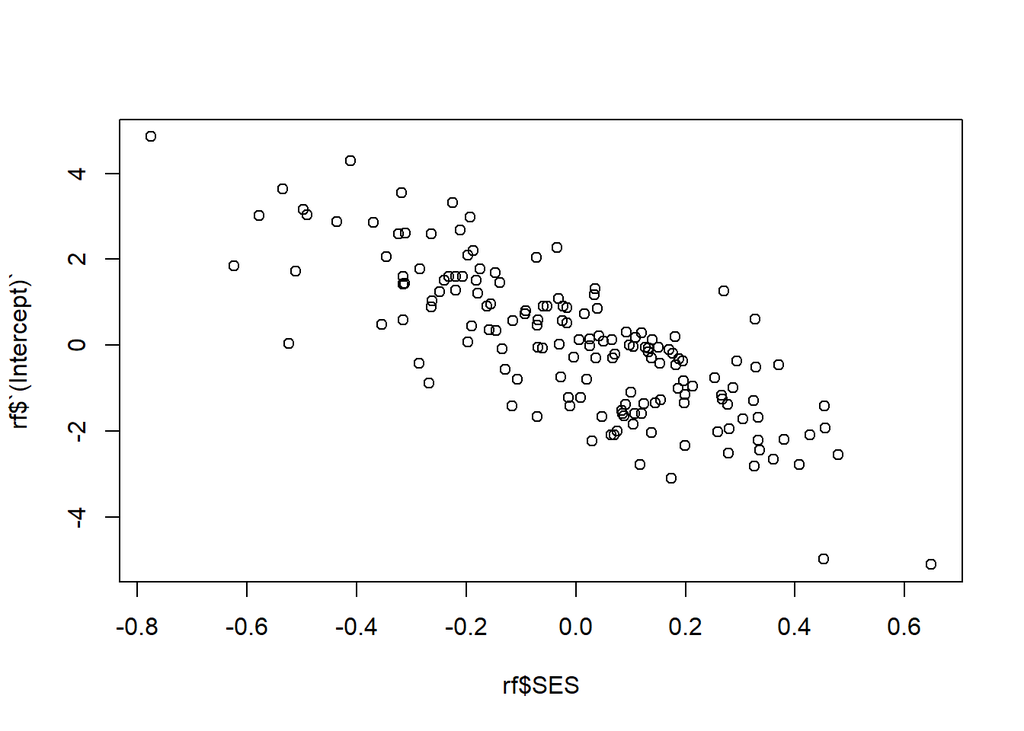

```r
## Visualize Correlation
rf <- ranef(mod4lmer)$School
plot(rf$SES,rf$`(Intercept)`)
```

- Can you interpret this graph? What do you think about the relationship between the slope and intercept?
- It looks like the higher the schools average math achievement score, the smaller the effect of SES on math achievement. Why would that be?
  - Possibly average SES is very important at lower performing schools, but less important at higher performing schools. This could be related to financial resources of the school…the lowest performing schools may have the least financial resources, and the SES of the student’s family matters. But the higher performing schools may have more financial resources, so the SES of the student’s family matters less. Just a hypothesis!

# Prediction from Random Effects Models

- Lets try to make some predictions from our model
- We may be interested in making marginal predictions (with respect to the random effects)
- Or we may be interested in making predictions conditional on random effects (conditional on a school here).
- The difference is whether or not we want to make the prediction for the average student at any school (marginal), or the student at a specific school (conditional)

```r
## Prediction Dataframe
mod4lmer <-
  lmer(MathAch ~ Minority + Sex + SES + (SES|School),
       data=MathAchieve_dt)
## School 7688,8627, 9586
pred_df <-
  expand.grid(Minority="Yes",Sex="Male",SES=c(-1,0,1),
            School=c(7688,8627,9586))
pred_df$Achieve_pred_conditional <-
  predict(mod4lmer,pred_df)
pred_df$Achieve_pred_marginal <-
  predict(mod4lmer,pred_df,re.form=NA)
pred_df
```

```
##   Minority  Sex SES School Achieve_pred_conditional Achieve_pred_marginal
## 1      Yes Male  -1   7688                13.231926              9.052151
## 2      Yes Male   0   7688                14.793429             11.147887
## 3      Yes Male   1   7688                16.354933             13.243623
## 4      Yes Male  -1   8627                 6.971225              9.052151
## 5      Yes Male   0   8627                 9.143119             11.147887
## 6      Yes Male   1   8627                11.315013             13.243623
## 7      Yes Male  -1   9586                 9.872050              9.052151
## 8      Yes Male   0   9586                11.874562             11.147887
## 9      Yes Male   1   9586                13.877074             13.243623
```

# lme4 Prediction Confidence Intervals

- Confidence intervals are tricky to calculate, with disagreement on how to calculate them
- The authors of lme4 suggest a bootstrapping approach, although this can be time consuming in bigger data sets
- Another package, called merTools, has a function for prediction intervals
- This function attempts to capture the uncertainty of both fixed effects and random effects

```r
library(merTools)
predictInterval(mod4lmer,pred_df)
```

```
##         fit      upr       lwr
## 1 13.242405 21.00805  5.797862
## 2 14.846349 22.27743  7.653103
## 3 16.163547 24.22463  8.592780
## 4  6.516212 14.84539 -1.125671
## 5  9.028859 16.76588  1.220474
## 6 11.532972 19.52653  2.951807
## 7  9.975940 17.66485  2.310267
## 8 11.729032 18.90478  4.776641
## 9 13.881179 21.24008  5.811102
```

# Extension to General Linear Models

- We can extend these random effects using the general linear model framework. Let’s think about a logistic regression as a first example.
- To keep things consistent, we will just discretize the math achievement score outcome into a ‘high’ and ‘low’ score based on scores above and below 10.

```r
# Discretize Math score
MathAchieve_dt[,MathAch_bin:=factor(ifelse(MathAch > 10, 'High','Low'))]
MathAchieve_dt
```

```
##       School Minority    Sex    SES MathAch MEANSES MathAch_bin
##    1:   1224       No Female -1.528   5.876  -0.428         Low
##    2:   1224       No Female -0.588  19.708  -0.428        High
##    3:   1224       No   Male -0.528  20.349  -0.428        High
##    4:   1224       No   Male -0.668   8.781  -0.428         Low
##    5:   1224       No   Male -0.158  17.898  -0.428        High
##   ---
## 7181:   9586       No Female  1.512  20.402   0.627        High
## 7182:   9586       No Female -0.038  14.794   0.627        High
## 7183:   9586       No Female  1.332  19.641   0.627        High
## 7184:   9586       No Female -0.008  16.241   0.627        High
## 7185:   9586       No Female  0.792  22.733   0.627        High
```

- Just as before, we expect the outcome of binary math score to be related to school (and potentially the other predictors).

```r
## Overall proportion of high scores
MathAchieve_dt[,list(Prop_High=sum(MathAch_bin=='High')/.N)]
```

```
##    Prop_High
## 1: 0.6431454
```

```r
## proportion by school
MathAchieve_dt[,list(Prop_High=sum(MathAch_bin=='High')/.N),
               by=School][,summary(Prop_High)]
```

```
##    Min. 1st Qu.  Median    Mean 3rd Qu.    Max.
## 0.07143 0.52495 0.65385 0.63339 0.76377 1.00000
```

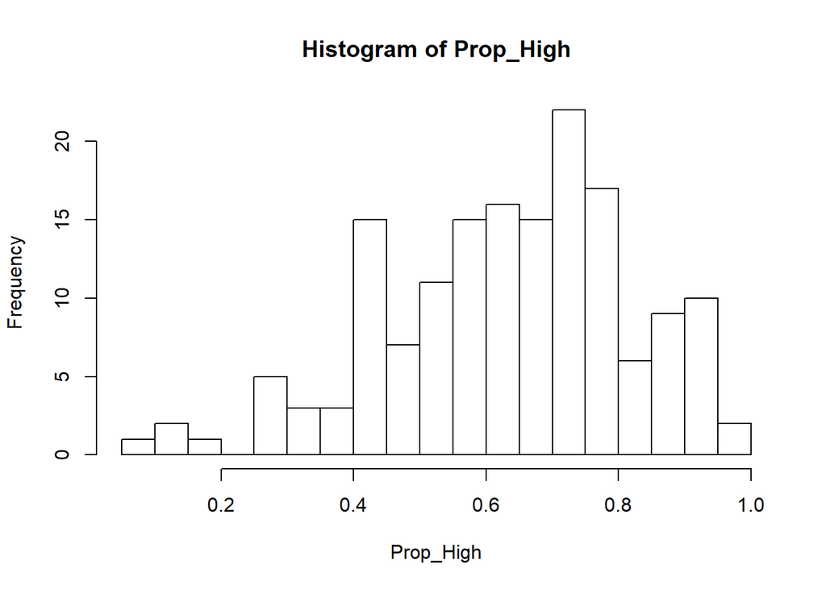

```
## $breaks
##  [1] 0.05 0.10 0.15 0.20 0.25 0.30 0.35 0.40 0.45 0.50 0.55 0.60 0.65 0.70 0.75 0.80 0.85 0.90 0.95 1.00
##
## $counts
##  [1]  1  2  1  0  5  3  3 15  7 11 15 16 15 22 17  6  9 10  2
##
## $density
##  [1] 0.125 0.250 0.125 0.000 0.625 0.375 0.375 1.875 0.875 1.375 1.875 2.000 1.875 2.750 2.125 0.750 1.125 1.250 0.250
##
## $mids
##  [1] 0.075 0.125 0.175 0.225 0.275 0.325 0.375 0.425 0.475 0.525 0.575 0.625 0.675 0.725 0.775 0.825 0.875 0.925 0.975
##
## $xname
## [1] "Prop_High"
##
## $equidist
## [1] TRUE
##
## attr(,"class")
## [1] "histogram"
```

```r
MathAchieve_dt[,list(Prop_High=sum(MathAch_bin=='High')/.N),
               by=School][,hist(Prop_High,breaks = 30)]
```

# Fitting a Logistic Regression

- We can try to fit a simple logistic regression (since the outcome is binary) using school as a predictor with the base R `glm()` function.

```r
## Fit logistic regression
glm_mod1 <- glm(MathAch_bin ~ School,
                data=MathAchieve_dt,
                family = binomial)
summary(glm_mod1)
```

```
##
## Call:
## glm(formula = MathAch_bin ~ School, family = binomial, data = MathAchieve_dt)
##
## Deviance Residuals:
##     Min       1Q   Median       3Q      Max
## -2.2974  -0.9116  -0.6152   1.0812   2.4267
##
## Coefficients:
##             Estimate Std. Error z value Pr(>|z|)
## (Intercept)   2.5649     1.0377   2.472 0.013449 *
## School8854   -0.8786     1.1463  -0.766 0.443417
## School4458   -0.7973     1.1154  -0.715 0.474742
## School5762   -0.7087     1.1438  -0.620 0.535532
## School6990   -1.5404     1.0835  -1.422 0.155108
## School5815   -1.9896     1.1183  -1.779 0.075214 .
## School7172   -2.0053     1.0840  -1.850 0.064332 .
## School4868   -3.3025     1.1006  -3.001 0.002694 **
## School7341   -2.8412     1.0756  -2.642 0.008252 **
## School1358   -3.1115     1.1047  -2.816 0.004855 **
## School4383   -2.8061     1.1132  -2.521 0.011712 *
## School2305   -3.4194     1.0715  -3.191 0.001417 **
## School8800   -1.7765     1.1056  -1.607 0.108099
## School3088   -2.2020     1.0876  -2.025 0.042902 *
## School8775   -2.2285     1.0783  -2.067 0.038759 *
## School7890   -1.8718     1.0794  -1.734 0.082905 .
## School6144   -2.2364     1.0828  -2.065 0.038884 *
## School6443   -2.2967     1.1012  -2.086 0.037015 *
## School5192   -2.7081     1.1048  -2.451 0.014237 *
## School6808   -2.4740     1.0807  -2.289 0.022072 *
## School2818   -3.4812     1.0925  -3.186 0.001440 **
## School9340   -2.6339     1.1023  -2.390 0.016869 *
## School4523   -2.2648     1.0789  -2.099 0.035793 *
## School6816   -3.9512     1.0911  -3.621 0.000293 ***
## School2277   -2.3344     1.0693  -2.183 0.029024 *
## School8009   -3.6354     1.0903  -3.334 0.000855 ***
## School5783   -3.3635     1.1127  -3.023 0.002504 **
## School3013   -3.1469     1.0766  -2.923 0.003466 **
## School7101   -3.0003     1.1075  -2.709 0.006750 **
## School4530   -2.0116     1.0702  -1.880 0.060169 .
```

[output cut: 125 more lines]

```
## School8202   -2.7368     1.0918  -2.507 0.012188 *
## School8627   -2.9079     1.0745  -2.706 0.006806 **
## School8628   -4.4558     1.1049  -4.033 5.51e-05 ***
## School9198   -4.4745     1.1679  -3.831 0.000127 ***
## School9586   -3.7326     1.0819  -3.450 0.000561 ***
## ---
## Signif. codes:  0 '***' 0.001 '**' 0.01 '*' 0.05 '.' 0.1 ' ' 1
##
## (Dispersion parameter for binomial family taken to be 1)
##
##     Null deviance: 9363.3  on 7184  degrees of freedom
## Residual deviance: 8241.5  on 7025  degrees of freedom
## AIC: 8561.5
##
## Number of Fisher Scoring iterations: 14
```

# Logistic Regression with Random Intercept

- Now let’s add a random intercept for each school. This is just like we learned before - we are now adding a shrinkage effect to estimate the school level effect. This is summarized as a single variance component for each school (variance due to school).
- Recall that logistic regression is a bit more complicated though…we need to think about whether we are working on the scale of the betas (right side of equation), or the scale of the outcome (left side - the probability of the event occuring).
- These effects are generally interpreted on the scale of the beta’s, just like a regular logistic regression.

```r
## Fit random intercept model by school
glmer_mod1 <- glmer(MathAch_bin ~ (1|School),
                    data=MathAchieve_dt,
                    family=binomial)
summary(glmer_mod1)
```

```
## Generalized linear mixed model fit by maximum likelihood (Laplace Approximation) ['glmerMod']
##  Family: binomial  ( logit )
## Formula: MathAch_bin ~ (1 | School)
##    Data: MathAchieve_dt
##
##      AIC      BIC   logLik deviance df.resid
##   8737.9   8751.6  -4366.9   8733.9     7183
##
## Scaled residuals:
##     Min      1Q  Median      3Q     Max
## -1.9876 -0.7185 -0.4997  0.9338  3.1527
##
## Random effects:
##  Groups Name        Variance Std.Dev.
##  School (Intercept) 0.7481   0.8649
## Number of obs: 7185, groups:  School, 160
##
## Fixed effects:
##             Estimate Std. Error z value Pr(>|z|)
## (Intercept) -0.64289    0.07396  -8.692   <2e-16 ***
## ---
## Signif. codes:  0 '***' 0.001 '**' 0.01 '*' 0.05 '.' 0.1 ' ' 1
```

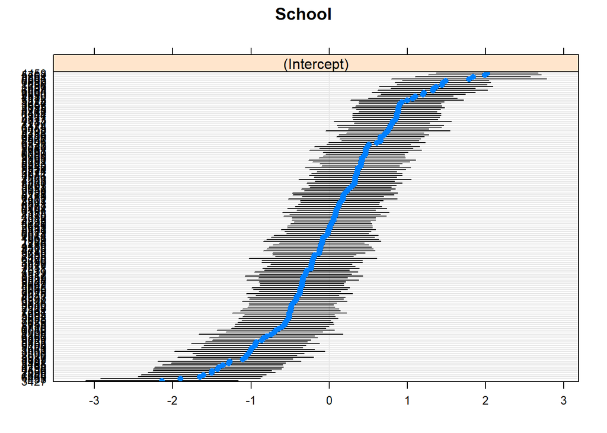

```r
dotplot(ranef(glmer_mod1))
```

# Logistic Regression with Random Intercept and Fixed Effects

```r
## Fit random intercept model with fixed effects
glmer_mod2 <- glmer(MathAch_bin ~ Minority + Sex + SES + (1|School),
                    data=MathAchieve_dt,
                    family=binomial)
summary(glmer_mod1) # note the p-values are there from lmertest package
```

```
## Generalized linear mixed model fit by maximum likelihood (Laplace Approximation) ['glmerMod']
##  Family: binomial  ( logit )
## Formula: MathAch_bin ~ (1 | School)
##    Data: MathAchieve_dt
##
##      AIC      BIC   logLik deviance df.resid
##   8737.9   8751.6  -4366.9   8733.9     7183
##
## Scaled residuals:
##     Min      1Q  Median      3Q     Max
## -1.9876 -0.7185 -0.4997  0.9338  3.1527
##
## Random effects:
##  Groups Name        Variance Std.Dev.
##  School (Intercept) 0.7481   0.8649
## Number of obs: 7185, groups:  School, 160
##
## Fixed effects:
##             Estimate Std. Error z value Pr(>|z|)
## (Intercept) -0.64289    0.07396  -8.692   <2e-16 ***
## ---
## Signif. codes:  0 '***' 0.001 '**' 0.01 '*' 0.05 '.' 0.1 ' ' 1
```

- Confidence intervals for the fixed effects can be obtained similarly as we saw before:

```r
## Get confidence intervals on the fixed effects
confint(glmer_mod2,method="Wald")
```

```
##                  2.5 %     97.5 %
## .sig01              NA         NA
## (Intercept) -1.1786883 -0.9114397
## MinorityYes  0.6801184  0.9757421
## SexFemale    0.1526514  0.3924817
## SES         -0.7634458 -0.6009392
```

```r
#confint(glmer_mod2,method="profile") # This takes awhile to run!
#confint(glmer_mod2,method="boot") # This takes awhile to run!
```

# Calculating ICC with a Logistic Regression

- Did you notice there is no residual variance in any of these logistic regression models? Why is that?
- Remember - there is no ‘sigma’ in a regular logistic regression! It uses the binomial distribution, where the variance is equal to $np(1-p)$
- So how do we calculate the ICC? According to one reference, the residual variance is fixed at $(pi ^2) / 3$ thus, we can calculate ICC according to: $intercept\_variance / (intercept\_variance + (pi ^2) / 3)$

Moineddin, R., Matheson, F. I., & Glazier, R. H. (2007). A simulation study of sample size for multilevel logistic regression models. BMC Medical Research Methodology, 7, 34

```r
## Calculate ICC
VarCorr(glmer_mod1)
```

```
##  Groups Name        Std.Dev.
##  School (Intercept) 0.8649
```

```r
0.8649 / (0.8649  + (pi ^2)/3)
```

```
## [1] 0.2081705
```

# Random Intercept and Slope

- You can specify the random slope just as we did before.

```r
glmer_mod3 <- glmer(MathAch_bin ~ Minority + Sex + SES + (SES||School),
                    data=MathAchieve_dt,
                    family=binomial)
summary(glmer_mod3) # note the p-values are there from lmertest package
```

```
## Generalized linear mixed model fit by maximum likelihood (Laplace Approximation) ['glmerMod']
##  Family: binomial  ( logit )
## Formula: MathAch_bin ~ Minority + Sex + SES + (SES || School)
##    Data: MathAchieve_dt
##
##      AIC      BIC   logLik deviance df.resid
##   8247.6   8288.8  -4117.8   8235.6     7179
##
## Scaled residuals:
##     Min      1Q  Median      3Q     Max
## -2.8236 -0.6659 -0.4347  0.8285  4.8812
##
## Random effects:
##  Groups   Name        Variance Std.Dev.
##  School   (Intercept) 0.35204  0.5933
##  School.1 SES         0.01707  0.1306
## Number of obs: 7185, groups:  School, 160
##
## Fixed effects:
##             Estimate Std. Error z value Pr(>|z|)
## (Intercept) -1.04504    0.06814 -15.336  < 2e-16 ***
## MinorityYes  0.83076    0.07565  10.981  < 2e-16 ***
## SexFemale    0.27234    0.06126   4.445 8.77e-06 ***
## SES         -0.68692    0.04357 -15.765  < 2e-16 ***
## ---
## Signif. codes:  0 '***' 0.001 '**' 0.01 '*' 0.05 '.' 0.1 ' ' 1
##
## Correlation of Fixed Effects:
##             (Intr) MnrtyY SexFml
## MinorityYes -0.335
## SexFemale   -0.492  0.026
## SES         -0.016  0.134  0.024
```

# Conclusion

Random effects modeling are a mathematically complex extension to regular linear regression. However, the simple assumptions of linear regression are sometimes violated and we must model the variance structures to get appropriate p-values. Additionally, we may be interested in the shrinkage effect of a random term if that fits the contextual framework of the situation.